# Evaluate 24 days of non attainment

J Hagy

2024-09-16

## Evaluating an unlikely scenario

Commenters noted that it was possible for POSAT to be less than the 66% criterion value for up to 24 days without violating the EPA’s criteria. For this to happen, POSAT would have to be less than 66% for the period June 18 - June 30 (12 days in the Spawning and Larval Development Season) and July 1 - July 12 (12 days in the Juvenile Development Season).

Here we evaluate if it is likely for this scenario to occur.

To begin, we need can compute the number of days that percent oxygen saturation was less than 66% in the period from June 19 and July 12 and relate it to the 10th percentile value of percent oxygen saturation in the *Juvenile Development* season. The number of attaining days is bounded by 0 and 24, so it can be expressed as a fraction on the interval (0,1) and modeled using beta regression.

```r
# What is the highest value in each year from June 18 to July 12
seasonalMax <- rbind(
  drc_summer %>% mutate(Site="Chester"),
  drpl_summer %>% mutate(Site="Penn's Landing")) %>%
  mutate(doy.as.date = as.Date(paste0("1970-",format(date,"%m-%d")))) %>%
  filter(between(doy.as.date,as.Date("1970-06-19"),as.Date("1970-07-12"))) %>%
  group_by(Site,year) %>%
  summarize(POSAT.max = max(posat.mean),
            POSAT.min = min(posat.mean))
numberAttains <- rbind(
  drc_summer %>% mutate(Site="Chester"),
  drpl_summer %>% mutate(Site="Penn's Landing")) %>%
  mutate(doy.as.date = as.Date(paste0("1970-",format(date,"%m-%d")))) %>%
  filter(between(doy.as.date,as.Date("1970-06-19"),as.Date("1970-07-12"))) %>%
  mutate(attains = cut(posat.mean,breaks = c(0,66,1000),labels=c("not attain","attain"))) %>%
  group_by(Site,year,attains) %>%
  summarize(n=n()) %>%
  pivot_wider(id_cols = c("Site","year"),names_from = "attains",values_from = "n",values_fill=0)
# Extract the POSAT 10th percentile from the percentiles variable
p10 <- percentiles %>%
  filter(percentile==0.1,type=="Observed") %>%
  mutate(p10=posat) %>%
  select(Site,year,p10)

# Years the 10th percentile criterion was attained.
p10[p10$p10>66,]
```

```
## # A tibble: 5 × 3
##   Site     year   p10
##   <chr>   <dbl> <dbl>
## 1 Chester  2013  67.3
## 2 Chester  2015  68.5
## 3 Chester  2016  69.5
## 4 Chester  2017  68.1
## 5 Chester  2018  71.6
```

```r
# Joint them together
df <- left_join(seasonalMax,p10,by=c("Site","year")) %>%
      left_join(.,numberAttains,by=c("Site","year")) %>%
  ungroup() %>%
  rename(not_attain = `not attain`) %>%
  mutate(frac_attaining = (24 - not_attain)/24)

summary(df)
```

```
##      Site                year        POSAT.max        POSAT.min
##  Length:41          Min.   :2002   Min.   : 54.72   Min.   :43.49
##  Class :character   1st Qu.:2007   1st Qu.: 70.87   1st Qu.:55.67
##  Mode  :character   Median :2012   Median : 82.32   Median :59.27
##                     Mean   :2012   Mean   : 82.03   Mean   :60.21
##                     3rd Qu.:2017   3rd Qu.: 91.64   3rd Qu.:66.55
##                     Max.   :2022   Max.   :117.07   Max.   :76.88
##       p10          not_attain         attain      frac_attaining
##  Min.   :45.70   Min.   : 0.000   Min.   : 0.00   Min.   :0.0000
##  1st Qu.:55.19   1st Qu.: 0.000   1st Qu.: 9.00   1st Qu.:0.3750
##  Median :60.63   Median : 6.000   Median :18.00   Median :0.7500
##  Mean   :59.79   Mean   : 8.561   Mean   :15.44   Mean   :0.6433
##  3rd Qu.:63.92   3rd Qu.:15.000   3rd Qu.:24.00   3rd Qu.:1.0000
##  Max.   :71.64   Max.   :24.000   Max.   :24.00   Max.   :1.0000
```

```r
beta_reg <- betareg(frac_attaining ~ p10,data=df %>% filter(Site=="Chester"))
summary(beta_reg)
```

```
##
## Call:
## betareg(formula = frac_attaining ~ p10, data = df %>% filter(Site ==
##     "Chester"))
##
## Randomized quantile residuals:
##     Min      1Q  Median      3Q     Max
## -1.6220 -0.7884 -0.0123  0.6761  2.1858
##
## Coefficients (mu model with logit link):
##             Estimate Std. Error z value Pr(>|z|)
## (Intercept) -9.63761    4.68547  -2.057   0.0397 *
## p10          0.16435    0.07761   2.118   0.0342 *
##
## Phi coefficients (phi model with identity link):
##       Estimate Std. Error z value Pr(>|z|)
## (phi)    3.706      3.828   0.968    0.333
##
## Exceedence parameter (extended-support xbetax model):
##         Estimate Std. Error z value Pr(>|z|)
## Log(nu)   -1.038      1.446  -0.718    0.473
## ---
## Signif. codes:  0 '***' 0.001 '**' 0.01 '*' 0.05 '.' 0.1 ' ' 1
##
## Exceedence parameter nu: 0.3542
## Type of estimator: ML (maximum likelihood)
## Log-likelihood: -12.24 on 4 Df
## Number of iterations in BFGS optimization: 19
```

```r
tmp <- data.frame(p10=seq(40,70))
tmp$pred_frac <- predict(beta_reg,tmp)
tmp[tmp$p10==66,]
```

```
##    p10 pred_frac
## 27  66 0.8334922
```

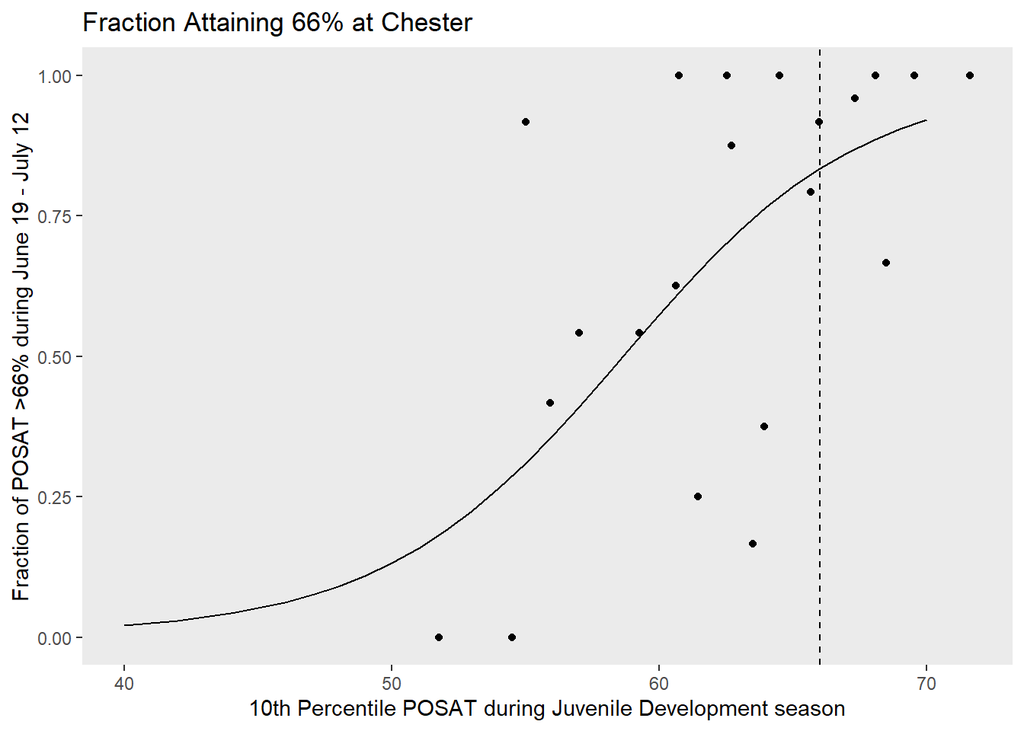

```r
# 0.8334922*24
# 20 days > 66% when P10 is 66%

ggplot()+
    geom_point(data=df %>% filter(Site=="Chester"),aes(x=p10,y=frac_attaining))+
    geom_vline(xintercept=66,linetype=2)+
    theme(panel.grid=element_blank())+
    geom_line(data=tmp,aes(x=as.numeric(p10),y=pred_frac))+
    labs(x="10th Percentile POSAT during Juvenile Development season",
         y="Fraction of POSAT >66% during June 19 - July 12")+
    ggtitle("Fraction Attaining 66% at Chester")
```

At Chester, we can predict that 20 of 24 days will have POSAT>66% if the 10th percentile of POSAT during the *Juvenile Development* season is 66%. During 2002-2022, when the 10th percentile of POSAT was >66%, 8 days in 2015 had POSAT<66% and 1 day in 2013. In 2016, 2017 and 2018, all the days during June 19 - July 12 had POSAT>66%.

```r
df[df$p10>66,]
```

```
## # A tibble: 5 × 8
##   Site     year POSAT.max POSAT.min   p10 not_attain attain frac_attaining
##   <chr>   <dbl>     <dbl>     <dbl> <dbl>      <int>  <int>          <dbl>
## 1 Chester  2013      87.2      65.3  67.3          1     23          0.958
## 2 Chester  2015      79.6      57.3  68.5          8     16          0.667
## 3 Chester  2016      79.3      68.6  69.5          0     24          1
## 4 Chester  2017      96.4      71.7  68.1          0     24          1
## 5 Chester  2018      94.9      73.3  71.6          0     24          1
```

We can fit the same model for Penn’s Landing.

```r
beta_reg <- betareg(frac_attaining ~ p10,data=df %>% filter(Site=="Penn's Landing"))
summary(beta_reg)
```

```
##
## Call:
## betareg(formula = frac_attaining ~ p10, data = df %>% filter(Site ==
##     "Penn's Landing"))
##
## Randomized quantile residuals:
##     Min      1Q  Median      3Q     Max
## -1.8156 -0.4747  0.0755  0.4702  1.4683
##
## Coefficients (mu model with logit link):
##              Estimate Std. Error z value Pr(>|z|)
## (Intercept) -17.93064    5.65517  -3.171  0.00152 **
## p10           0.32293    0.09972   3.238  0.00120 **
##
## Phi coefficients (phi model with identity link):
##       Estimate Std. Error z value Pr(>|z|)
## (phi)    3.030      2.048   1.479    0.139
##
## Exceedence parameter (extended-support xbetax model):
##         Estimate Std. Error z value Pr(>|z|)
## Log(nu)   -2.114      1.409    -1.5    0.134
## ---
## Signif. codes:  0 '***' 0.001 '**' 0.01 '*' 0.05 '.' 0.1 ' ' 1
##
## Exceedence parameter nu: 0.1207
## Type of estimator: ML (maximum likelihood)
## Log-likelihood: -8.274 on 4 Df
## Number of iterations in BFGS optimization: 21
```

```r
tmp <- data.frame(p10=seq(40,70))
tmp$pred_frac <- predict(beta_reg,tmp)
tmp[tmp$p10==66,]
```

```
##    p10 pred_frac
## 27  66 0.9782295
```

```r
 0.9782295*24
```

```
## [1] 23.47751
```

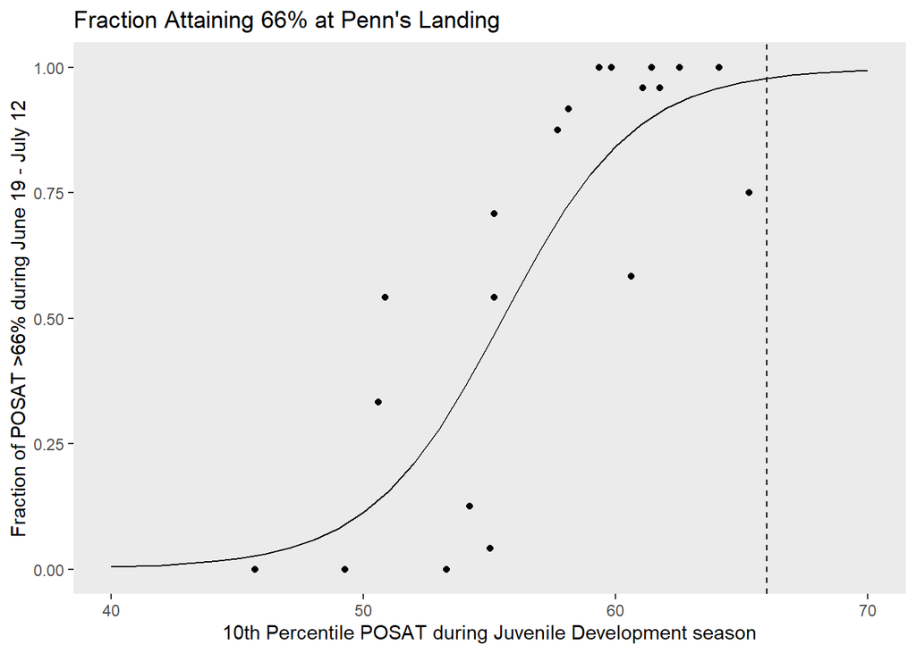

```r
ggplot()+
    geom_point(data=df %>% filter(Site=="Penn's Landing"),aes(x=p10,y=frac_attaining))+
    geom_vline(xintercept=66,linetype=2)+
    theme(panel.grid=element_blank())+
    geom_line(data=tmp,aes(x=as.numeric(p10),y=pred_frac))+
    labs(x="10th Percentile POSAT during Juvenile Development season",
         y="Fraction of POSAT >66% during June 19 - July 12")+
    ggtitle("Fraction Attaining 66% at Penn's Landing")
```

At Penn’s Landing, when the 10th percentile of POSAT during the *Juvenile Development* season is 66%, we can expect that POSAT will be less than 66% less than 1 day during June 19 - July 12.

Based on this analysis, it can be concluded that the commenters scenario is extremely unlikely.